# IODS course project

Juuso Jalasto

# Introduction to Open Data Science - Course Project

# About the project

This project is created for the Introduction to open data science 2021 MOOC. The course exists as an introduction to data science in an open environment utilizing R and GitHub. This course is part of my Phd courses in the University of Helsinki.

https://github.com/JuusoPJ/IODS-project

```r
date()
```

```
## [1] "Fri Dec 10 20:55:08 2021"
```

# Regression and model validation

This week we have the learning 2014 data, already changed with the script found in

https://github.com/JuusoPJ/IODS-project/tree/master/data

```r
# read file made with script
students2014 = read.csv("learning2014.csv", as.is = TRUE, header = TRUE)

# remove the first x index column
students2014 = students2014[c(2,3,4,5,6,7,8)]
```

```r
str(students2014)
```

```
## 'data.frame':    166 obs. of  7 variables:
##  $ gender  : chr  "F" "M" "F" "M" ...
##  $ age     : int  53 55 49 53 49 38 50 37 37 42 ...
##  $ attitude: int  37 31 25 35 37 38 35 29 38 21 ...
##  $ deep    : num  3.58 2.92 3.5 3.5 3.67 ...
##  $ stra    : num  3.38 2.75 3.62 3.12 3.62 ...
##  $ surf    : num  2.58 3.17 2.25 2.25 2.83 ...
##  $ points  : int  25 12 24 10 22 21 21 31 24 26 ...
```

The data consists of 166 observations with 7 variables.

```r
# access the GGally and ggplot2 libraries
library(GGally)
library(ggplot2)
```

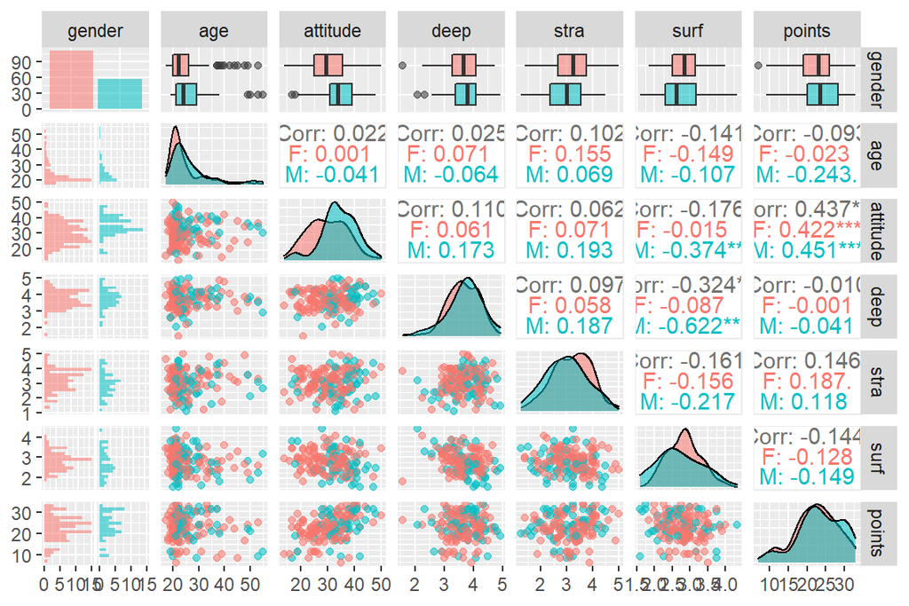

```r
# create a more advanced plot matrix with ggpairs()
p = ggpairs(students2014, mapping = aes(col = gender, alpha = 0.3), lower = list(combo = wrap("facethist", bins = 20)))
p
```

```r
# load corrplot package to plot correlations between all the variables (similar but far less heavy than ggplot)
library(corrplot)
# create vector for just numeric variables
x = students2014[, c("age", "attitude", "deep", "stra","surf","points")]
# correlation matrix
cor(x, use = "pairwise")
```

```
##                  age    attitude        deep        stra       surf      points
## age       1.00000000  0.02220071  0.02507804  0.10244409 -0.1414052 -0.09319032
## attitude  0.02220071  1.00000000  0.11024302  0.06174177 -0.1755422  0.43652453
## deep      0.02507804  0.11024302  1.00000000  0.09650255 -0.3238020 -0.01014849
## stra      0.10244409  0.06174177  0.09650255  1.00000000 -0.1609729  0.14612247
## surf     -0.14140516 -0.17554218 -0.32380198 -0.16097287  1.0000000 -0.14435642
## points   -0.09319032  0.43652453 -0.01014849  0.14612247 -0.1443564  1.00000000
```

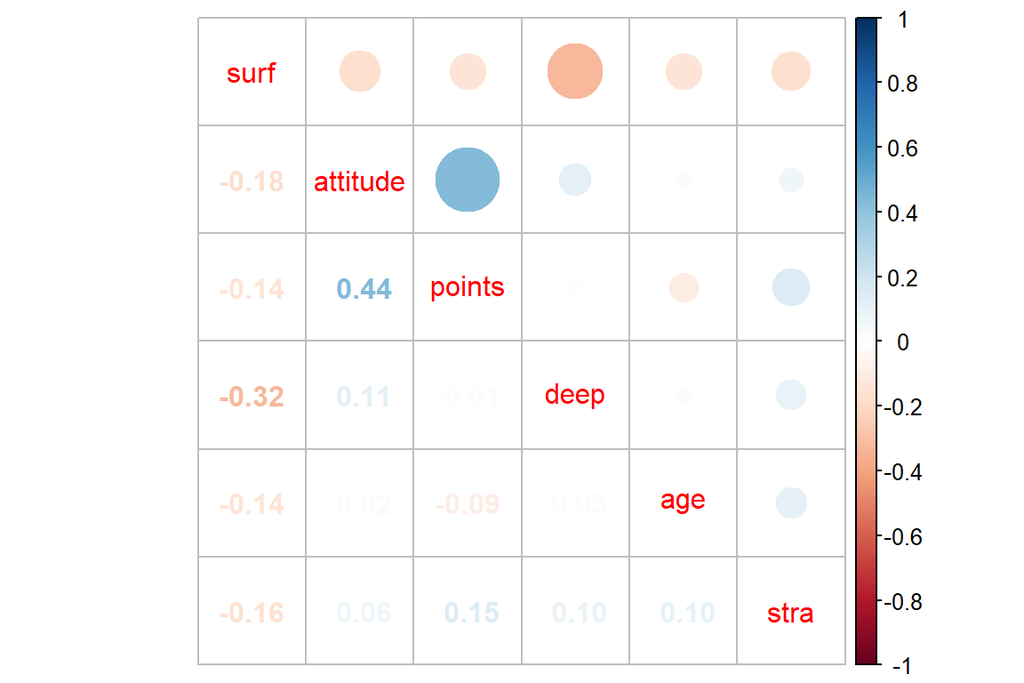

```r
# graphical representation of correlations from corrplot package
corrplot.mixed(cor(x, use = "pairwise"), order ="hclust")
```

```r
# linear model with three most correlated variable
lm.p = lm(points ~ attitude + surf + stra, data = students2014)
summary(lm.p)
```

```
##
## Call:
## lm(formula = points ~ attitude + surf + stra, data = students2014)
##
## Residuals:
##      Min       1Q   Median       3Q      Max
## -17.1550  -3.4346   0.5156   3.6401  10.8952
##
## Coefficients:
##             Estimate Std. Error t value Pr(>|t|)
## (Intercept) 11.01711    3.68375   2.991  0.00322 **
## attitude     0.33952    0.05741   5.913 1.93e-08 ***
## surf        -0.58607    0.80138  -0.731  0.46563
## stra         0.85313    0.54159   1.575  0.11716
## ---
## Signif. codes:  0 '***' 0.001 '**' 0.01 '*' 0.05 '.' 0.1 ' ' 1
##
## Residual standard error: 5.296 on 162 degrees of freedom
## Multiple R-squared:  0.2074, Adjusted R-squared:  0.1927
## F-statistic: 14.13 on 3 and 162 DF,  p-value: 3.156e-08
```

The model explains 20% of the variance of points, with only attitude having a significant p-value and so differing from null hypothesis.

```r
# new model with the only significant effect
lm.pn = lm(points ~attitude, data = students2014)
summary(lm.pn)
```

```
##
## Call:
## lm(formula = points ~ attitude, data = students2014)
##
## Residuals:
##      Min       1Q   Median       3Q      Max
## -16.9763  -3.2119   0.4339   4.1534  10.6645
##
## Coefficients:
##             Estimate Std. Error t value Pr(>|t|)
## (Intercept) 11.63715    1.83035   6.358 1.95e-09 ***
## attitude     0.35255    0.05674   6.214 4.12e-09 ***
## ---
## Signif. codes:  0 '***' 0.001 '**' 0.01 '*' 0.05 '.' 0.1 ' ' 1
##
## Residual standard error: 5.32 on 164 degrees of freedom
## Multiple R-squared:  0.1906, Adjusted R-squared:  0.1856
## F-statistic: 38.61 on 1 and 164 DF,  p-value: 4.119e-09
```

The model now explains 19% of the variance of points with points increasing 0.35 for every 1 increase in attitude.

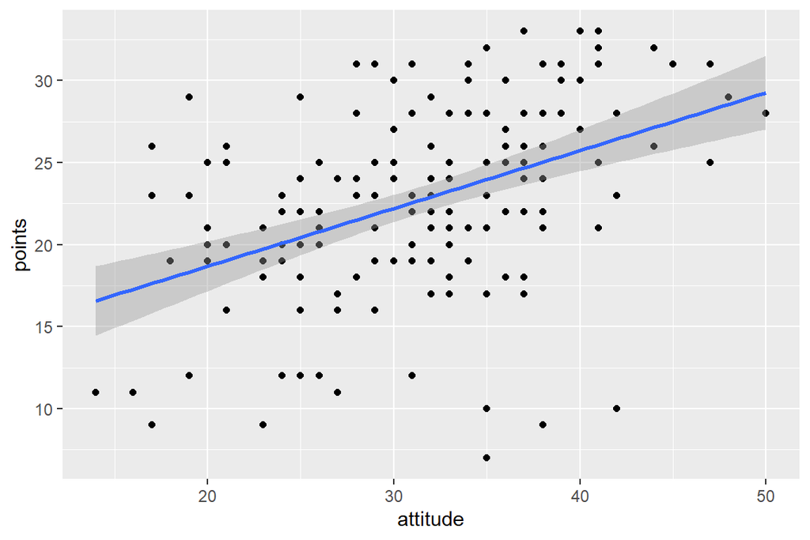

```r
# scatter plot with the linear model line
qplot(attitude, points, data = students2014) + geom_smooth(method = "lm")
```

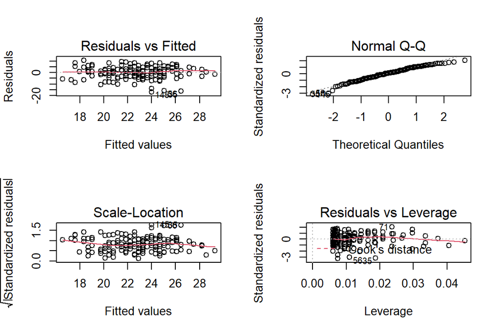

```r
# plot to 2x2 area
par(mfrow = c(2,2))

# automatically generates 4 typically used diagnostic plots
plot(lm.pn)
```

1. Residuals do not show a pattern where the distribution of residuals varies depending on fitted values.
2. QQ-plot seems to be nicely on the line making the SEs and P-values of the model coefficient reliable.
3. Standardized residuals vs fitted should show a similar magnitude along y-axis of each region on the x-axis, which it does.

```r
date()
```

```
## [1] "Fri Dec 10 20:55:15 2021"
```

# Logistic regression

This week we will learn about logistic regression.

First we read the data file made in the data wrangling part and remove the first column created in the csv saving process as it is not needed.

```r
# read file made with script
pormath = read.csv("pormath.csv", as.is = TRUE, header = TRUE)

# remove the first x index column, all in all 52 variables with x
pormath = pormath[c(2:52)]
```

Then we look at the data to make sure everything looks okay. Let us also load to the dplyr package as we will have need of it.

```r
library(dplyr)
glimpse(pormath)
```

```
## Rows: 370
## Columns: 51
## $ school     <chr> "GP", "GP", "GP", "GP", "GP", "GP", "GP", "GP", "GP", "GP",~
## $ sex        <chr> "F", "F", "F", "F", "F", "F", "F", "F", "F", "F", "F", "F",~
## $ age        <int> 15, 15, 15, 15, 15, 15, 15, 15, 15, 15, 15, 15, 15, 15, 15,~
## $ address    <chr> "R", "R", "R", "R", "R", "R", "R", "R", "R", "U", "U", "U",~
## $ famsize    <chr> "GT3", "GT3", "GT3", "GT3", "GT3", "GT3", "GT3", "LE3", "LE~
## $ Pstatus    <chr> "T", "T", "T", "T", "T", "T", "T", "T", "T", "A", "A", "T",~
## $ Medu       <int> 1, 1, 2, 2, 3, 3, 3, 2, 3, 3, 4, 1, 1, 1, 1, 1, 2, 2, 2, 3,~
## $ Fedu       <int> 1, 1, 2, 4, 3, 4, 4, 2, 1, 3, 3, 1, 1, 1, 2, 2, 1, 2, 3, 2,~
## $ Mjob       <chr> "at_home", "other", "at_home", "services", "services", "ser~
## $ Fjob       <chr> "other", "other", "other", "health", "services", "health", ~
## $ reason     <chr> "home", "reputation", "reputation", "course", "reputation",~
## $ guardian   <chr> "mother", "mother", "mother", "mother", "other", "mother", ~
## $ traveltime <int> 2, 1, 1, 1, 2, 1, 2, 2, 2, 1, 1, 3, 1, 1, 1, 1, 3, 1, 2, 1,~
```

[output cut: 38 more lines]

We have 370 observations with 51 variables so everything looks to be correct. This data comes from the UCI machine learning repository (https://archive.ics.uci.edu/ml/datasets/Student+Performance). The data looks at the student achievement in secondary education of two Portuguese schools. The variable list is and information is as follows:

1. school - student’s school (binary: ‘GP’ - Gabriel Pereira or ‘MS’ - Mousinho da Silveira)
2. sex - student’s sex (binary: ‘F’ - female or ‘M’ - male)
3. age - student’s age (numeric: from 15 to 22)
4. address - student’s home address type (binary: ‘U’ - urban or ‘R’ - rural)
5. famsize - family size (binary: ‘LE3’ - less or equal to 3 or ‘GT3’ - greater than 3)
6. Pstatus - parent’s cohabitation status (binary: ‘T’ - living together or ‘A’ - apart)
7. Medu - mother’s education (numeric: 0 - none, 1 - primary education (4th grade), 2 – 5th to 9th grade, 3 – secondary education or 4 – higher education)
8. Fedu - father’s education (numeric: 0 - none, 1 - primary education (4th grade), 2 – 5th to 9th grade, 3 – secondary education or 4 – higher education)
9. Mjob - mother’s job (nominal: ‘teacher’, ‘health’ care related, civil ‘services’ (e.g. administrative or police), ‘at_home’ or ‘other’)
10. Fjob - father’s job (nominal: ‘teacher’, ‘health’ care related, civil ‘services’ (e.g. administrative or police), ‘at_home’ or ‘other’)
11. reason - reason to choose this school (nominal: close to ‘home’, school ‘reputation’, ‘course’ preference or ‘other’)
12. guardian - student’s guardian (nominal: ‘mother’, ‘father’ or ‘other’)
13. traveltime - home to school travel time (numeric: 1 - <15 min., 2 - 15 to 30 min., 3 - 30 min. to 1 hour, or 4 - >1 hour)
14. studytime - weekly study time (numeric: 1 - <2 hours, 2 - 2 to 5 hours, 3 - 5 to 10 hours, or 4 - >10 hours)
15. failures - number of past class failures (numeric: n if 1<=n<3, else 4)
16. schoolsup - extra educational support (binary: yes or no)
17. famsup - family educational support (binary: yes or no)
18. paid - extra paid classes within the course subject (Math or Portuguese) (binary: yes or no)
19. activities - extra-curricular activities (binary: yes or no)
20. nursery - attended nursery school (binary: yes or no)
21. higher - wants to take higher education (binary: yes or no)
22. internet - Internet access at home (binary: yes or no)
23. romantic - with a romantic relationship (binary: yes or no)
24. famrel - quality of family relationships (numeric: from 1 - very bad to 5 - excellent)
25. freetime - free time after school (numeric: from 1 - very low to 5 - very high)
26. goout - going out with friends (numeric: from 1 - very low to 5 - very high)
27. Dalc - workday alcohol consumption (numeric: from 1 - very low to 5 - very high)
28. Walc - weekend alcohol consumption (numeric: from 1 - very low to 5 - very high)
29. health - current health status (numeric: from 1 - very bad to 5 - very good)
30. absences - number of school absences (numeric: from 0 to 93)

We have also created during the data wrangling a new variables called alc_use which is the mean alcohol used from workday and weekend and with that the logical variable high_use which gives TRUE if the mean alc_use is over 2.

Our interest is to study the relationship of high/low alcohol consumption to the other variables. For this the interesting values could be the following four:

1. Sex (male/female)
2. family relationship (1 - very bad to 5 - excellent)
3. number of past class failures (n = 1-3 or 4 for > 3)
4. going out with friends (1 very low to 5 ver high)

My hypothesis is that alcohol consumption is connected with male sex, poor family relationship, higher number of class failures and higher amount of going out with friends.

First, lets do a quick barplot of all of them.

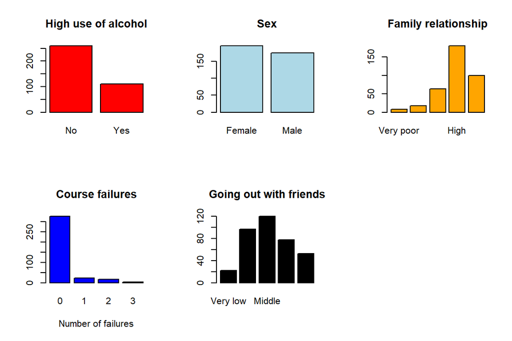

```r
# first define 2x3 figure square
par(mfrow = c(2,3))
# next barplots, we use the names.arg to define names for the barplots
barplot(table(pormath$high_use), col = "red", main = "High use of alcohol", names.arg=c("No", "Yes"))
barplot(table(pormath$sex), col = "lightblue", main = "Sex", names.arg=c("Female", "Male"))
barplot(table(pormath$famrel), col = "orange", main = "Family relationship", names.arg=c("Very poor", "Poor", "Middle", "High", "Very high"))
barplot(table(pormath$failures), col = "blue", main = "Course failures", xlab = "Number of failures")
barplot(table(pormath$goout), col = "black", main = "Going out with friends", names.arg=c("Very low", "Low", "Middle", "High", "Very high"))
```

Next, we will look at the cross-tabulations using the **CrossTable**-function found in the *gmodels*-package. We will also see the values of each indivual variable.

```r
# load package gmodels
library(gmodels)
# crosstable function, prop.t and prop.r are set false as we are interested in the column percentages.
CrossTable(pormath$high_use, pormath$sex, prop.t = FALSE, prop.r = FALSE, prop.c = TRUE, fisher =TRUE)
```

```
##
##
##    Cell Contents
## |-------------------------|
## |                       N |
## | Chi-square contribution |
## |           N / Col Total |
## |-------------------------|
##
##
## Total Observations in Table:  370
##
##
##                  | pormath$sex
## pormath$high_use |         F |         M | Row Total |
## -----------------|-----------|-----------|-----------|
##            FALSE |       154 |       105 |       259 |
##                  |     2.244 |     2.500 |           |
##                  |     0.790 |     0.600 |           |
## -----------------|-----------|-----------|-----------|
##             TRUE |        41 |        70 |       111 |
##                  |     5.235 |     5.833 |           |
##                  |     0.210 |     0.400 |           |
## -----------------|-----------|-----------|-----------|
##     Column Total |       195 |       175 |       370 |
##                  |     0.527 |     0.473 |           |
## -----------------|-----------|-----------|-----------|
##
##
## Fisher's Exact Test for Count Data
## ------------------------------------------------------------
## Sample estimate odds ratio:  2.497689
##
## Alternative hypothesis: true odds ratio is not equal to 1
## p =  0.0001023997
## 95% confidence interval:  1.545641 4.074193
##
## Alternative hypothesis: true odds ratio is less than 1
## p =  0.9999796
## 95% confidence interval:  0 3.778519
##
## Alternative hypothesis: true odds ratio is greater than 1
## p =  5.375988e-05
## 95% confidence interval:  1.661201 Inf
##
##
##
```

From this we can gather that 21% females have high use of alcohol while 40% of males have high alcohol use. We use Fishers exact test to look whether these are significantly different and with the p-value of 0.0001 we can say that high alcohol is different in males and females.

Next we look at the relationship of family relations to high alcohol consumption

```r
# crosstable function, again with similar arguments as previously
CrossTable(pormath$high_use, pormath$famrel, prop.t = FALSE, prop.r = FALSE, prop.c = TRUE, fisher = TRUE)
```

```
##
##
##    Cell Contents
## |-------------------------|
## |                       N |
## | Chi-square contribution |
## |           N / Col Total |
## |-------------------------|
##
##
## Total Observations in Table:  370
##
##
##                  | pormath$famrel
## pormath$high_use |         1 |         2 |         3 |         4 |         5 | Row Total |
## -----------------|-----------|-----------|-----------|-----------|-----------|-----------|
##            FALSE |         6 |         9 |        39 |       128 |        77 |       259 |
##                  |     0.029 |     1.029 |     0.751 |     0.032 |     0.700 |           |
##                  |     0.750 |     0.500 |     0.609 |     0.711 |     0.770 |           |
## -----------------|-----------|-----------|-----------|-----------|-----------|-----------|
##             TRUE |         2 |         9 |        25 |        52 |        23 |       111 |
##                  |     0.067 |     2.400 |     1.752 |     0.074 |     1.633 |           |
##                  |     0.250 |     0.500 |     0.391 |     0.289 |     0.230 |           |
## -----------------|-----------|-----------|-----------|-----------|-----------|-----------|
##     Column Total |         8 |        18 |        64 |       180 |       100 |       370 |
##                  |     0.022 |     0.049 |     0.173 |     0.486 |     0.270 |           |
## -----------------|-----------|-----------|-----------|-----------|-----------|-----------|
##
##
## Fisher's Exact Test for Count Data
## ------------------------------------------------------------
## Alternative hypothesis: two.sided
## p =  0.07362437
##
##
```

Our assumption that poorer family relations would mean more alcohol use do not seem supported by the cross tabulation and fishers exact test. This could be due to the very low number of participants with bad family relationship as the number of high alcohol users does increase with the decreasing number of family relationship status down to the middle value of 3.

Thirdly we look at the value of the number of past class failures.

```r
# crosstable function, again with similar arguments as previously
CrossTable(pormath$high_use, pormath$failures, prop.t = FALSE, prop.r = FALSE, prop.c = TRUE, fisher = TRUE)
```

```
##
##
##    Cell Contents
## |-------------------------|
## |                       N |
## | Chi-square contribution |
## |           N / Col Total |
## |-------------------------|
##
##
## Total Observations in Table:  370
##
##
##                  | pormath$failures
## pormath$high_use |         0 |         1 |         2 |         3 | Row Total |
## -----------------|-----------|-----------|-----------|-----------|-----------|
##            FALSE |       238 |        12 |         8 |         1 |       259 |
##                  |     0.485 |     1.371 |     1.278 |     1.157 |           |
##                  |     0.732 |     0.500 |     0.471 |     0.250 |           |
## -----------------|-----------|-----------|-----------|-----------|-----------|
##             TRUE |        87 |        12 |         9 |         3 |       111 |
##                  |     1.131 |     3.200 |     2.982 |     2.700 |           |
##                  |     0.268 |     0.500 |     0.529 |     0.750 |           |
## -----------------|-----------|-----------|-----------|-----------|-----------|
##     Column Total |       325 |        24 |        17 |         4 |       370 |
##                  |     0.878 |     0.065 |     0.046 |     0.011 |           |
## -----------------|-----------|-----------|-----------|-----------|-----------|
##
##
## Fisher's Exact Test for Count Data
## ------------------------------------------------------------
## Alternative hypothesis: two.sided
## p =  0.002064523
##
##
```

Students with 0 failures seem to have the least amount of high alcohol use and the the statistical test seem to indicate that there is a significant difference even though the n-values for higher failures are fairly low. We do not however know the cause-effect of the situation, whether alcohol use causes failures or is due to failures or is a mixed bag of both.

Finally we look at going out with friends variable.

```r
# crosstable function, again with similar arguments as previously, this time we use the chi-square test
CrossTable(pormath$high_use, pormath$goout, prop.t = FALSE, prop.r = FALSE, prop.c = TRUE, chisq= TRUE)
```

```
##
##
##    Cell Contents
## |-------------------------|
## |                       N |
## | Chi-square contribution |
## |           N / Col Total |
## |-------------------------|
##
##
## Total Observations in Table:  370
##
##
##                  | pormath$goout
## pormath$high_use |         1 |         2 |         3 |         4 |         5 | Row Total |
## -----------------|-----------|-----------|-----------|-----------|-----------|-----------|
##            FALSE |        19 |        82 |        97 |        40 |        21 |       259 |
##                  |     0.842 |     2.928 |     2.012 |     3.904 |     6.987 |           |
##                  |     0.864 |     0.845 |     0.808 |     0.513 |     0.396 |           |
## -----------------|-----------|-----------|-----------|-----------|-----------|-----------|
##             TRUE |         3 |        15 |        23 |        38 |        32 |       111 |
##                  |     1.964 |     6.832 |     4.694 |     9.109 |    16.303 |           |
##                  |     0.136 |     0.155 |     0.192 |     0.487 |     0.604 |           |
## -----------------|-----------|-----------|-----------|-----------|-----------|-----------|
##     Column Total |        22 |        97 |       120 |        78 |        53 |       370 |
##                  |     0.059 |     0.262 |     0.324 |     0.211 |     0.143 |           |
## -----------------|-----------|-----------|-----------|-----------|-----------|-----------|
##
##
## Statistics for All Table Factors
##
##
## Pearson's Chi-squared test
## ------------------------------------------------------------
## Chi^2 =  55.57422     d.f. =  4     p =  2.462684e-11
##
##
##
```

It would seem that going out with friends more does indicate more high alcohol use which is as expected. The p-value calculate with chi-square is also very low indicating good statistical significance in this. Alcohol consumption in portugues students seems to relate with social interaction rather than lone drinking.

Next, let us do a quick correlation table between the variables with the *corrplot*-function.

```r
# load corrplot library
library(corrplot)
```

```r
# first we need to change the sex variable into a numeric variable for correlation (female = 1, male = 2). For some reason this had to be done through transformation to a factor variable first rather than straight as.numeric transformation of a chr variable

pormath$sex = as.factor(pormath$sex)
pormath$sex = as.numeric(pormath$sex)

# first we create a vector with the variables of interest
pm.used = pormath[, c("high_use", "sex", "famrel", "failures","goout")]
# correlation matrix of variables
cor(pm.used, use = "pairwise")
```

```
##            high_use        sex      famrel    failures      goout
## high_use  1.0000000 0.20672456 -0.12183507  0.19062193 0.35635793
## sex       0.2067246 1.00000000  0.06157247  0.08643101 0.06561963
## famrel   -0.1218351 0.06157247  1.00000000 -0.05044315 0.05741374
## failures  0.1906219 0.08643101 -0.05044315  1.00000000 0.13720589
## goout     0.3563579 0.06561963  0.05741374  0.13720589 1.00000000
```

We can use corrplot to get us a graphical representation of the correlations.

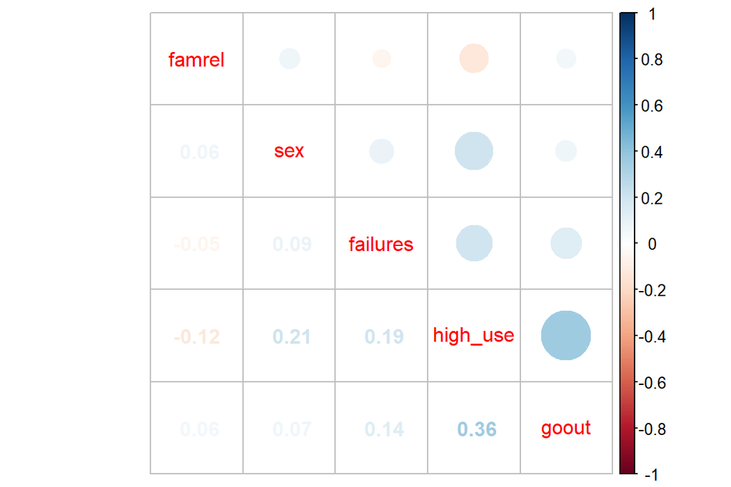

```r
corrplot.mixed(cor(pm.used, use = "pairwise"), order ="hclust")
```

It doesn’t seem that the explaining variables correlate with each other that strongly which is good for the logistic regression model. This way we can forehand avoid problems such as multicollinearity.

Now that we have explored our variables of interest, we will form a logistic regression model. We need to first make the categorical variables into factorial variables to see the odds between their categories. Sex as a dichotomous variable does not need this for now.

```r
# make the non-dichotomous variables into factorial variables
pormath$famrel = factor(pormath$famrel)
pormath$failures = factor(pormath$failures)
pormath$goout = factor(pormath$goout)
```

Next we need to change the reference category of family relationship (famrel) to 5 (very good) from 1 which is the automatic one.

```r
# change the reference category
pormath$famrel = relevel(pormath$famrel, ref = "5")
```

Now we can form the model and summarize it.

```r
# we use the glm-function with the family set to binomial to get a binomial logistic regression model
pm.1 <- glm(high_use ~ sex + famrel + failures + goout, data = pormath, family = "binomial")

# summary of the model
summary(pm.1)
```

```
##
## Call:
## glm(formula = high_use ~ sex + famrel + failures + goout, family = "binomial",
##     data = pormath)
##
## Deviance Residuals:
##     Min       1Q   Median       3Q      Max
## -1.8332  -0.7618  -0.4718   0.7412   2.4854
##
## Coefficients:
##             Estimate Std. Error z value Pr(>|z|)
## (Intercept)  -4.3132     0.8431  -5.116 3.12e-07 ***
## sex           1.0505     0.2675   3.926 8.62e-05 ***
## famrel1       0.8790     0.9779   0.899  0.36876
## famrel2       1.1459     0.6115   1.874  0.06093 .
## famrel3       1.3436     0.4104   3.274  0.00106 **
## famrel4       0.5618     0.3324   1.690  0.09102 .
## failures1     1.1042     0.5026   2.197  0.02801 *
## failures2     0.3233     0.5863   0.551  0.58130
## failures3     1.7605     1.2727   1.383  0.16657
## goout2        0.2207     0.7240   0.305  0.76052
## goout3        0.5615     0.7045   0.797  0.42538
## goout4        2.0203     0.7046   2.867  0.00414 **
## goout5        2.4273     0.7254   3.346  0.00082 ***
## ---
## Signif. codes:  0 '***' 0.001 '**' 0.01 '*' 0.05 '.' 0.1 ' ' 1
##
## (Dispersion parameter for binomial family taken to be 1)
##
##     Null deviance: 452.04  on 369  degrees of freedom
## Residual deviance: 363.53  on 357  degrees of freedom
## AIC: 389.53
##
## Number of Fisher Scoring iterations: 4
```

Let us calculate the odd’s ratios of the model and print them out.

```r
# calculate odds ratios
OR = coef(pm.1) %>% exp

# compute confidence intervals (CI)
CI = confint(pm.1) %>% exp
# print out the odds ratios with their confidence intervals
cbind(OR, CI)
```

```
##                      OR       2.5 %       97.5 %
## (Intercept)  0.01339058 0.002133242   0.06192559
## sex          2.85907269 1.704306439   4.87713555
## famrel1      2.40839871 0.273270377  14.41444487
## famrel2      3.14514296 0.949165410  10.65020253
## famrel3      3.83284170 1.731102395   8.70117933
## famrel4      1.75388121 0.925263051   3.42208968
## failures1    3.01678342 1.124453251   8.18079782
## failures2    1.38170471 0.434362679   4.44955310
## failures3    5.81536464 0.585465642 136.03658514
## goout2       1.24693632 0.338855793   6.34008849
## goout3       1.75337876 0.501457166   8.68316869
## goout4       7.54069423 2.165645648  37.42409729
## goout5      11.32813319 3.089131042  57.65819824
```

From these results it would seem that high alcohol use is related to male sex with OR **2.86 (95% CI 1.70-4.88)**.

From family relationships the result is not as good as we would expect that the worst relations would also have the worst OR but it is the middle relationship that has the significant OR of **3.83 (1.73-8.70)**, this is likely due to the very small number of cases with family relationship < 3, and as an afterthought those two (cat 1 and 2 of famrel) could possibly be combined for better results.

Failures has a similar problem with the category of single failure having an significant OR of **3.02 (1.12-8.18)** and the others not.

Going out seems to be the most logical of the factorial variables with the highest going out (cat 5 of goout) having an OR of **11.3 (3.09-57.7)**, however the 95% CI range is very large already suggesting some problems with the n-values possibly in reference category, and again combining categories could offer more reliable results.

Next let us explore the predictive power of the model. First we will add a probability prediction to the data set and then compare the predictions to the reality of high_use.

```r
# predicting the probability
prob = predict(pm.1, type = "response")
# add these to the data
pormath = mutate(pormath, probability = prob)
# add a new variable for the prediction of high_use
pormath = mutate(pormath, prediction = probability > 0.5)
# tabulate the target variable versus the predictions to see how many predictions go correct
table(high_use = pormath$high_use, prediction = pormath$prediction)
```

```
##         prediction
## high_use FALSE TRUE
##    FALSE   239   20
##    TRUE     53   58
```

Our sensitivity seems not that good while our specificity seems to be much better with only 20 cases that we predicted to have been high_use actually informed not have high use. We can calculate the sensitivity and specificity from this.

```r
table(high_use = pormath$high_use, prediction = pormath$prediction) %>% prop.table %>% addmargins
```

```
##         prediction
## high_use      FALSE       TRUE        Sum
##    FALSE 0.64594595 0.05405405 0.70000000
##    TRUE  0.14324324 0.15675676 0.30000000
##    Sum   0.78918919 0.21081081 1.00000000
```

The training error(proportion of wrongly classified individuals) is 0.054+0.143 = 0.197, some 20 of all cases. We can also compute a loss model for this same figure.

```r
loss_func = function(class, prob) {
  n_wrong = abs(class - prob) > 0.5
  mean(n_wrong)
}
loss_func(class = pormath$high_use, prob = pormath$probability)
```

```
## [1] 0.1972973
```

This is effectively the same as the summed up number from the table.

Let us look at this graphically with **ggplot**-package.

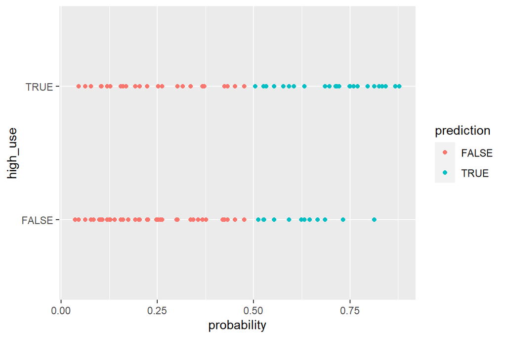

```r
library(ggplot2)
# initialize a plot of 'high_use' versus 'probability' in 'alc'
g = ggplot(pormath, aes(x = probability, y = high_use, col = prediction))

# define the geom as points and draw the plot
g + geom_point()
```

It would seem our model works better to close out high alcohol users rather than finding them (specificity > sensitivity).

Lets compare this to a coin toss probability with the *sample*-function.

```r
# generate 370 coin tosses with TRUE or FALSE as result
coin = c(TRUE,FALSE)
cointoss = sample(coin, size = 370, replace = TRUE)
```

Then we add this to the data.

```r
# add these to the data
pormath = mutate(pormath, coinpred = cointoss)
# tabulate the target variable versus the predictions to see how many coin tosses go correct
table(high_use = pormath$high_use, prediction = pormath$coinpred)
```

```
##         prediction
## high_use FALSE TRUE
##    FALSE   130  129
##    TRUE     56   55
```

```r
table(high_use = pormath$high_use, prediction = pormath$coinpred) %>% prop.table %>% addmargins
```

```
##         prediction
## high_use     FALSE      TRUE       Sum
##    FALSE 0.3513514 0.3486486 0.7000000
##    TRUE  0.1513514 0.1486486 0.3000000
##    Sum   0.5027027 0.4972973 1.0000000
```

We can see that completely randomly chosen cases would have the same sensitivity as our model did while the specificity is much better in our model. The training error is also around 50% as is expected from a coin toss. This again is indicative that our model could not find new cases of high alcohol use any better than a random coin toss would but those it would find would have a good chance of being high alcohol users.

We can also do a cross-validation test for this model.

```r
# K-fold cross-validation
library(boot)
cv = cv.glm(data = pormath, cost = loss_func, glmfit = pm.1, K = 10)

# average number of wrong predictions in the cross validation
cv$delta[1]
```

```
## [1] 0.2108108
```

It does seem that this model does have a slightly better test set performance with the error prediction being around 0.21-0.22 compared to the datacamp one which had around 0.26.

```r
date()
```

```
## [1] "Fri Dec 10 20:55:16 2021"
```

# Clustering and classification

This week we will learn about clustering and classifying data.

First we load up the Boston data from MASS package (https://stat.ethz.ch/R-manual/R-devel/library/MASS/html/Boston.html).

```r
# load up the MASS package and then boston
library(MASS)
data("Boston")
```

Let’s explore the data. As this data is loaded straight from the package we don’t have an extra id column at start like in the previous weeks with the wrangled data.

```r
# we use str and summary functions
str(Boston)
```

```
## 'data.frame':    506 obs. of  14 variables:
##  $ crim   : num  0.00632 0.02731 0.02729 0.03237 0.06905 ...
##  $ zn     : num  18 0 0 0 0 0 12.5 12.5 12.5 12.5 ...
##  $ indus  : num  2.31 7.07 7.07 2.18 2.18 2.18 7.87 7.87 7.87 7.87 ...
##  $ chas   : int  0 0 0 0 0 0 0 0 0 0 ...
##  $ nox    : num  0.538 0.469 0.469 0.458 0.458 0.458 0.524 0.524 0.524 0.524 ...
##  $ rm     : num  6.58 6.42 7.18 7 7.15 ...
##  $ age    : num  65.2 78.9 61.1 45.8 54.2 58.7 66.6 96.1 100 85.9 ...
##  $ dis    : num  4.09 4.97 4.97 6.06 6.06 ...
##  $ rad    : int  1 2 2 3 3 3 5 5 5 5 ...
##  $ tax    : num  296 242 242 222 222 222 311 311 311 311 ...
##  $ ptratio: num  15.3 17.8 17.8 18.7 18.7 18.7 15.2 15.2 15.2 15.2 ...
##  $ black  : num  397 397 393 395 397 ...
##  $ lstat  : num  4.98 9.14 4.03 2.94 5.33 ...
##  $ medv   : num  24 21.6 34.7 33.4 36.2 28.7 22.9 27.1 16.5 18.9 ...
```

```r
summary(Boston)
```

```
##       crim                zn             indus            chas
##  Min.   : 0.00632   Min.   :  0.00   Min.   : 0.46   Min.   :0.00000
##  1st Qu.: 0.08205   1st Qu.:  0.00   1st Qu.: 5.19   1st Qu.:0.00000
##  Median : 0.25651   Median :  0.00   Median : 9.69   Median :0.00000
##  Mean   : 3.61352   Mean   : 11.36   Mean   :11.14   Mean   :0.06917
##  3rd Qu.: 3.67708   3rd Qu.: 12.50   3rd Qu.:18.10   3rd Qu.:0.00000
##  Max.   :88.97620   Max.   :100.00   Max.   :27.74   Max.   :1.00000
##       nox               rm             age              dis
##  Min.   :0.3850   Min.   :3.561   Min.   :  2.90   Min.   : 1.130
##  1st Qu.:0.4490   1st Qu.:5.886   1st Qu.: 45.02   1st Qu.: 2.100
##  Median :0.5380   Median :6.208   Median : 77.50   Median : 3.207
##  Mean   :0.5547   Mean   :6.285   Mean   : 68.57   Mean   : 3.795
##  3rd Qu.:0.6240   3rd Qu.:6.623   3rd Qu.: 94.08   3rd Qu.: 5.188
##  Max.   :0.8710   Max.   :8.780   Max.   :100.00   Max.   :12.127
##       rad              tax           ptratio          black
##  Min.   : 1.000   Min.   :187.0   Min.   :12.60   Min.   :  0.32
##  1st Qu.: 4.000   1st Qu.:279.0   1st Qu.:17.40   1st Qu.:375.38
##  Median : 5.000   Median :330.0   Median :19.05   Median :391.44
##  Mean   : 9.549   Mean   :408.2   Mean   :18.46   Mean   :356.67
##  3rd Qu.:24.000   3rd Qu.:666.0   3rd Qu.:20.20   3rd Qu.:396.23
##  Max.   :24.000   Max.   :711.0   Max.   :22.00   Max.   :396.90
##      lstat            medv
##  Min.   : 1.73   Min.   : 5.00
##  1st Qu.: 6.95   1st Qu.:17.02
##  Median :11.36   Median :21.20
##  Mean   :12.65   Mean   :22.53
##  3rd Qu.:16.95   3rd Qu.:25.00
##  Max.   :37.97   Max.   :50.00
```

This is a pre-made data available with the MASS package with 14 variables and 506 observations. The 14 columns are as follow:

1. **crim** per capita crime rate by town.
2. **zn** proportion of residential land zoned for lots over 25,000 sq.ft.
3. **indus** proportion of non-retail business acres per town.
4. **chas** Charles River dummy variable (= 1 if tract bounds river; 0 otherwise).
5. **nox** nitrogen oxides concentration (parts per 10 million).
6. **rm** average number of rooms per dwelling.
7. **age** proportion of owner-occupied units built prior to 1940.
8. **dis** weighted mean of distances to five Boston employment centres.
9. **rad** index of accessibility to radial highways.
10. **tax** full-value property-tax rate per $10,000.
11. **ptratio** pupil-teacher ratio by town.
12. **black** 1000(Bk - 0.63)^2 where Bk is the proportion of blacks by town.
13. **lstat** lower status of the population (percent).
14. **medv** median value of owner-occupied homes in $1000s.

Let us visualize the data with the *pairs*-function for a portion of the data (the full set of 14 variables is too much for the pairs function to print out in a readable form).

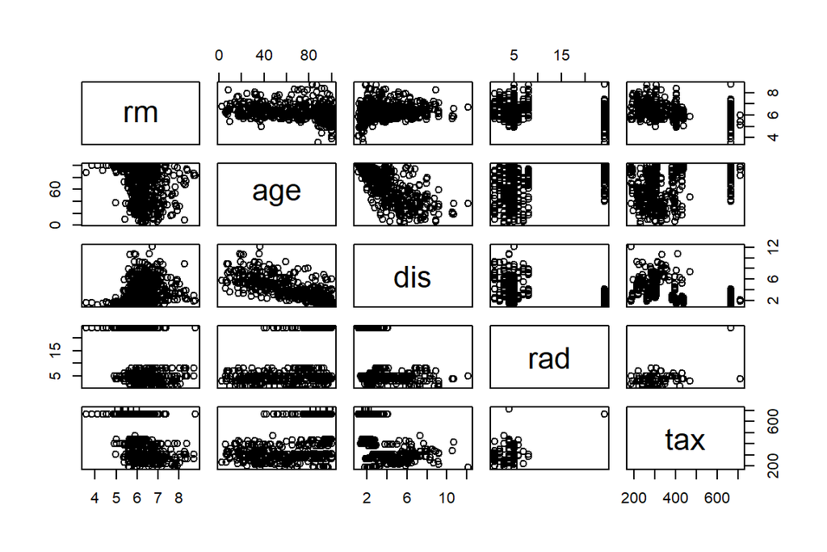

```r
pairs(Boston[6:10])
```

This is not entirely useful so let us try the *corrplot*-package, we also load the *dplyr*-package.

```r
# first load the the corrplot and dplyr package
library(corrplot)
library(dplyr)
```

```r
# show a correlation matrix with digits rounded to 2
cor_matrix = cor(Boston, use = "pairwise")
cor_matrix %>% round(digits = 2)
```

```
##          crim    zn indus  chas   nox    rm   age   dis   rad   tax ptratio
## crim     1.00 -0.20  0.41 -0.06  0.42 -0.22  0.35 -0.38  0.63  0.58    0.29
## zn      -0.20  1.00 -0.53 -0.04 -0.52  0.31 -0.57  0.66 -0.31 -0.31   -0.39
## indus    0.41 -0.53  1.00  0.06  0.76 -0.39  0.64 -0.71  0.60  0.72    0.38
## chas    -0.06 -0.04  0.06  1.00  0.09  0.09  0.09 -0.10 -0.01 -0.04   -0.12
## nox      0.42 -0.52  0.76  0.09  1.00 -0.30  0.73 -0.77  0.61  0.67    0.19
## rm      -0.22  0.31 -0.39  0.09 -0.30  1.00 -0.24  0.21 -0.21 -0.29   -0.36
## age      0.35 -0.57  0.64  0.09  0.73 -0.24  1.00 -0.75  0.46  0.51    0.26
## dis     -0.38  0.66 -0.71 -0.10 -0.77  0.21 -0.75  1.00 -0.49 -0.53   -0.23
## rad      0.63 -0.31  0.60 -0.01  0.61 -0.21  0.46 -0.49  1.00  0.91    0.46
## tax      0.58 -0.31  0.72 -0.04  0.67 -0.29  0.51 -0.53  0.91  1.00    0.46
## ptratio  0.29 -0.39  0.38 -0.12  0.19 -0.36  0.26 -0.23  0.46  0.46    1.00
## black   -0.39  0.18 -0.36  0.05 -0.38  0.13 -0.27  0.29 -0.44 -0.44   -0.18
## lstat    0.46 -0.41  0.60 -0.05  0.59 -0.61  0.60 -0.50  0.49  0.54    0.37
## medv    -0.39  0.36 -0.48  0.18 -0.43  0.70 -0.38  0.25 -0.38 -0.47   -0.51
##         black lstat  medv
## crim    -0.39  0.46 -0.39
## zn       0.18 -0.41  0.36
## indus   -0.36  0.60 -0.48
## chas     0.05 -0.05  0.18
## nox     -0.38  0.59 -0.43
## rm       0.13 -0.61  0.70
## age     -0.27  0.60 -0.38
## dis      0.29 -0.50  0.25
## rad     -0.44  0.49 -0.38
## tax     -0.44  0.54 -0.47
## ptratio -0.18  0.37 -0.51
## black    1.00 -0.37  0.33
## lstat   -0.37  1.00 -0.74
## medv     0.33 -0.74  1.00
```

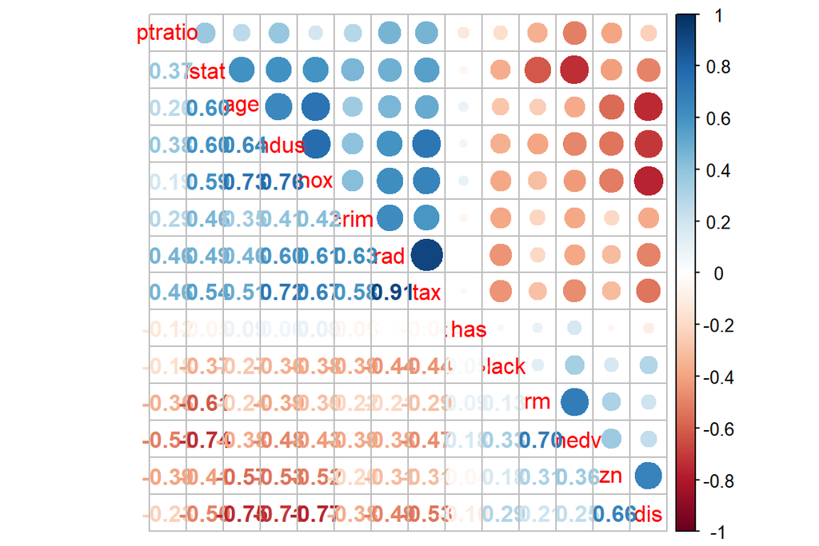

```r
# visualizing the corrplot matrix
corrplot.mixed(cor_matrix, order="hclust")
```

From the corrplot values and images we can see strong (>0.50) correlations between several variables. The dummy variable chas unsuprisingly does not correlate with the others strongly.

The variables seem to divide in two regarding correlation with each other. Inside the variables corrolate with each other positively but negatively with the the other group of variables.

1. ptratio, lstat, ag, indus, nox, crim, rad and tax.
2. black, rm, medv, zn, dis

Next let us standardize the variables using the *scale*-function.

```r
# use the scale function on the dataset
boston_s = scale(Boston)
```

Summarizing the new scaled and centered variables.

```r
summary(boston_s)
```

```
##       crim                 zn               indus              chas
##  Min.   :-0.419367   Min.   :-0.48724   Min.   :-1.5563   Min.   :-0.2723
##  1st Qu.:-0.410563   1st Qu.:-0.48724   1st Qu.:-0.8668   1st Qu.:-0.2723
##  Median :-0.390280   Median :-0.48724   Median :-0.2109   Median :-0.2723
##  Mean   : 0.000000   Mean   : 0.00000   Mean   : 0.0000   Mean   : 0.0000
##  3rd Qu.: 0.007389   3rd Qu.: 0.04872   3rd Qu.: 1.0150   3rd Qu.:-0.2723
##  Max.   : 9.924110   Max.   : 3.80047   Max.   : 2.4202   Max.   : 3.6648
##       nox                rm               age               dis
##  Min.   :-1.4644   Min.   :-3.8764   Min.   :-2.3331   Min.   :-1.2658
##  1st Qu.:-0.9121   1st Qu.:-0.5681   1st Qu.:-0.8366   1st Qu.:-0.8049
##  Median :-0.1441   Median :-0.1084   Median : 0.3171   Median :-0.2790
##  Mean   : 0.0000   Mean   : 0.0000   Mean   : 0.0000   Mean   : 0.0000
##  3rd Qu.: 0.5981   3rd Qu.: 0.4823   3rd Qu.: 0.9059   3rd Qu.: 0.6617
##  Max.   : 2.7296   Max.   : 3.5515   Max.   : 1.1164   Max.   : 3.9566
##       rad               tax             ptratio            black
##  Min.   :-0.9819   Min.   :-1.3127   Min.   :-2.7047   Min.   :-3.9033
##  1st Qu.:-0.6373   1st Qu.:-0.7668   1st Qu.:-0.4876   1st Qu.: 0.2049
##  Median :-0.5225   Median :-0.4642   Median : 0.2746   Median : 0.3808
##  Mean   : 0.0000   Mean   : 0.0000   Mean   : 0.0000   Mean   : 0.0000
##  3rd Qu.: 1.6596   3rd Qu.: 1.5294   3rd Qu.: 0.8058   3rd Qu.: 0.4332
##  Max.   : 1.6596   Max.   : 1.7964   Max.   : 1.6372   Max.   : 0.4406
##      lstat              medv
##  Min.   :-1.5296   Min.   :-1.9063
##  1st Qu.:-0.7986   1st Qu.:-0.5989
##  Median :-0.1811   Median :-0.1449
##  Mean   : 0.0000   Mean   : 0.0000
##  3rd Qu.: 0.6024   3rd Qu.: 0.2683
##  Max.   : 3.5453   Max.   : 2.9865
```

We can see the class of the scaled and centered object with *class*.

```r
class(boston_s)
```

```
## [1] "matrix" "array"
```

Let’s make the matrix variable into a new data frame.

```r
# using the as.data.frame on the matrix
boston_scaled = as.data.frame(boston_s)
```

The scaling effectively changes the variables into a z-scores by substracting the values with its expected value and dividing this difference by its standard deviation.

Next we create a categorical variable of the crime rate from the scaled Boston dataset. First we compute the quantiles of the crim variable

```r
# create a new quantile vector called bins and check it
bins = quantile(boston_scaled$crim)
bins
```

```
##           0%          25%          50%          75%         100%
## -0.419366929 -0.410563278 -0.390280295  0.007389247  9.924109610
```

Next we use the quantile vector to create a new variable. We will also name the categories made with the quantile vector as follows:

0-25 low

25-50 med_low

50-75 med_high

75-100 high

```r
# create a factorial variabl with cut function and using the quantile of boston_scaled$crim as breaks, also label the new categories accordingly.
crime = cut(boston_scaled$crim, breaks = bins, include.lowest = TRUE, labels = c("low", "med_low", "med_high", "high"))
```

Lets have a look at our categorical variable.

```r
table(crime)
```

```
## crime
##      low  med_low med_high     high
##      127      126      126      127
```

These now seem to confer to the quantile vector with roughly equal sizes.

We are now ready to remove the original variable and insert the new variable to the data set.

```r
# use the dplyr:: handle so in case another package also has a similarly named function
boston_scaled = dplyr::select(boston_scaled, -crim)
boston_scaled = data.frame(boston_scaled, crime)
```

Next we divide the data set between a training set(80%) and test set(20%). We start by getting the row number (aka number of observations) for boston_scaled. From there we can choose 80% with the *sample*-function.

```r
# row and sample size
n = nrow(boston_scaled)
ind = sample(n, size = n*0.8)

# train and test set
train = boston_scaled[ind,]
test = boston_scaled[-ind,]
```

Next we save up the test data set crime and remove it.

```r
# save the crime column of test data set and remove it with select, call dplyr:: just in case again
correct_classes = test$crime
test = dplyr::select(test, -crime)
```

Now we are ready to do some analysis with the linear discriminant method. This method finds the linear combination of the variables that separate the target variable classes. This time our target variable will be the crime variable from the train data set. We do the analysis with the *lda*-function.

```r
table(train$crime)
```

```
##
##      low  med_low med_high     high
##      106       95      103      100
```

```r
# use of lda is similar to linear regression model, we also use the ~. to indicate the function to use all variables available in the data set
# we utilize the MASS-package, note that this will mask select from dplyr-package which is why used the dplyr:: earlier
library(MASS)
lda.fit = lda(crime~., data = train)
lda.fit
```

```
## Call:
## lda(crime ~ ., data = train)
##
## Prior probabilities of groups:
##       low   med_low  med_high      high
## 0.2623762 0.2351485 0.2549505 0.2475248
##
## Group means:
##                   zn      indus         chas        nox          rm        age
## low       1.04966245 -0.9250013 -0.123759247 -0.9023729  0.43607520 -0.9332257
## med_low  -0.09457588 -0.3291744  0.017773055 -0.5779353 -0.08478477 -0.2846205
## med_high -0.37734151  0.1401069  0.224586496  0.3600557  0.20364442  0.4048812
## high     -0.48724019  1.0171519  0.003267949  1.0968889 -0.38933634  0.8197880
##                 dis        rad        tax     ptratio       black       lstat
## low       0.9699676 -0.6936710 -0.7251713 -0.45226011  0.37415284 -0.78160081
## med_low   0.3392867 -0.5454537 -0.4860731 -0.07281424  0.32669469 -0.16919349
## med_high -0.3593613 -0.3786473 -0.2917410 -0.27812965  0.08049398 -0.01088402
## high     -0.8655744  1.6377820  1.5138081  0.78037363 -0.71174246  0.89379384
##                 medv
## low       0.53874888
## med_low   0.01520318
## med_high  0.26002375
## high     -0.67105975
##
## Coefficients of linear discriminants:
##                 LD1          LD2           LD3
## zn       0.10188365  0.737965254 -8.161507e-01
## indus   -0.04361091 -0.214487989  2.822634e-01
## chas    -0.06709609 -0.065794781  9.768840e-02
## nox      0.46238860 -0.637542759 -1.558258e+00
## rm      -0.06831615 -0.175780290 -1.960691e-01
## age      0.27905311 -0.258015430  1.265205e-05
## dis     -0.06875438 -0.207809510 -2.851640e-02
## rad      2.89718814  1.058530660  6.799746e-02
## tax      0.08844608 -0.101283429  4.774314e-01
## ptratio  0.17662375 -0.026396795 -3.163680e-01
## black   -0.13614743  0.002311909  1.210940e-01
## lstat    0.32909683 -0.334250456  1.897610e-01
## medv     0.27090933 -0.395968744 -3.285581e-01
##
## Proportion of trace:
##    LD1    LD2    LD3
## 0.9453 0.0417 0.0130
```

Next lets draw a plot of the model

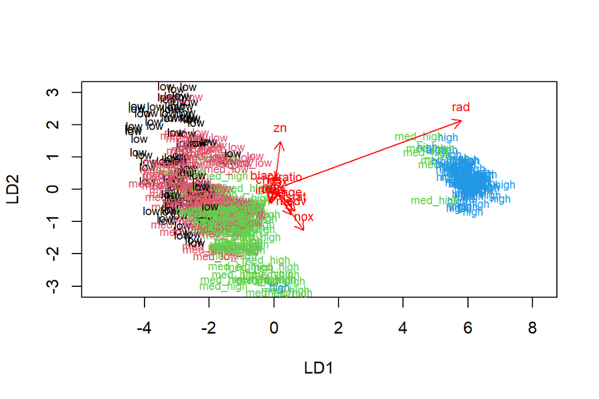

```r
# this is a function from the datacamp course for the arrows for the plot
lda.arrows = function(x, myscale = 1, arrow_heads = 0.1, color = "red", tex = 0.75, choices = c(1,2)){
  heads = coef(x)
  arrows(x0 = 0, y0 = 0,
         x1 = myscale * heads[,choices[1]],
         y1 = myscale * heads[,choices[2]], col=color, length = arrow_heads)
  text(myscale * heads[,choices], labels = row.names(heads),
       cex = tex, col=color, pos=3)
}

#next is the actual plot with the arrows added
plot(lda.fit, dimen = 2, col = as.numeric(train$crime), pch = as.numeric(train$crime))
lda.arrows(lda.fit, myscale = 2)
```

You may notice that this looks like a negative of the data camp results, this is because the datacamp actually has stored in the exercise a different order of variables (high, low, med_high, med_low) and this uses the order (low, med_low, med_high, high). The models are otherwise identical and the random sampling only gives a small variance to the results.

Next we will predict the classes of of the crime variable to the test data.

```r
# predict classes with test data
lda.pred <- predict(lda.fit, newdata = test)

# cross tabulate the results
table(correct = correct_classes, predicted = lda.pred$class)
```

```
##           predicted
## correct    low med_low med_high high
##   low        9      10        2    0
##   med_low    6      17        8    0
##   med_high   0       8       15    0
##   high       0       0        0   27
```

The results are similar to the datacamp results with the high crime rate prediction being the best. For the others there is some deviance and the results seem a bit worse. Again the order of the categories is different here.